# Optimization Methods

Jacob Seedorff

2022-05-20

# Introduction

This document demonstrates the utility of the different optimization methods and the parallel computation for fitting glms employed by **BranchGLM**.

# Loading packages

```r
library(BranchGLM)
library(microbenchmark)
library(ggplot2)
```

# Methods

## Fisher’s scoring

Fisher’s scoring is similar to newton-raphson, except it uses the expected information instead of the observed information. Fisher’s scoring and newton-raphson are the same when the canonical link is used. This algorithm is usually very fast when there are not very many predictors.

## BFGS and L-BFGS

BFGS is a quasi-newton method where instead of using the inverse information, we instead approximate it using all the previous gradients. L-BFGS is a limited memory variant of BFGS that uses the m previous gradients to approximate the inverse information instead of using all the previous gradients. 5 and 10 are typical choices for m. BFGS and L-BFGS typically converge at about the same rate.

BFGS and L-BFGS are typically faster than Fisher’s scoring when there are a large number of predictors. This is because the expected information can take very long to calculate when there is a lot of predictors. But when there are not very many predictors, Fisher’s scoring is usually the fastest of these methods.

# Simulations

```r
LogisticSimul <- function(n, d, Bprob = .5, sd = 3){

  x <- MASS::mvrnorm(n, mu = rep(1, d), Sigma = diag(.5, nrow = d, ncol = d) +
                 matrix(.5, ncol = d, nrow = d))

  beta <- rnorm(d + 1, mean = 0, sd = sd)

  beta[sample(2:length(beta), floor((length(beta) - 1) * Bprob))] = 0

  p <- 1/(1 + exp(-x %*% beta[-1] - beta[1]))

  y <- rbinom(n, 1, p)

  df <- cbind(y, x) |>
    as.data.frame()
  df
}
```

## Small number of predictors

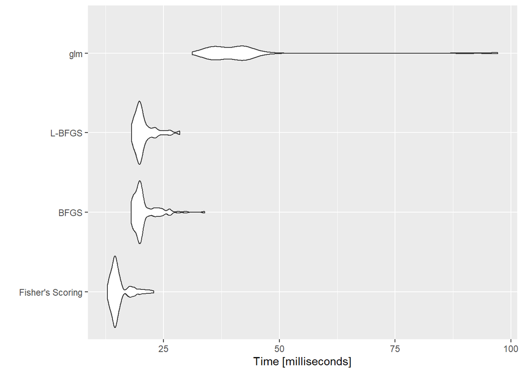

```r
set.seed(18076)

LogisticData <- LogisticSimul(10000, 5)

Times <- microbenchmark("Fisher's Scoring" = BranchGLM(y ~ ., data = LogisticData,
                                              family = "binomial", link = "logit",
                                              method = "Fisher"),
               "BFGS" = BranchGLM(y ~ ., data = LogisticData,
                                              family = "binomial", link = "logit",
                                              method = "BFGS"),
               "L-BFGS" = BranchGLM(y ~ ., data = LogisticData,
                                              family = "binomial", link = "logit",
                                              method = "LBFGS") ,
               "glm" = glm(y ~ ., data = LogisticData, family = binomial))

autoplot(Times, log = FALSE)
```

Fisher’s scoring is quite a bit faster than the other methods when the number of covariates is small. All of the methods available from the function `BranchGLM` are faster than the built-in glm function for this simulation.

## Medium number of predictors

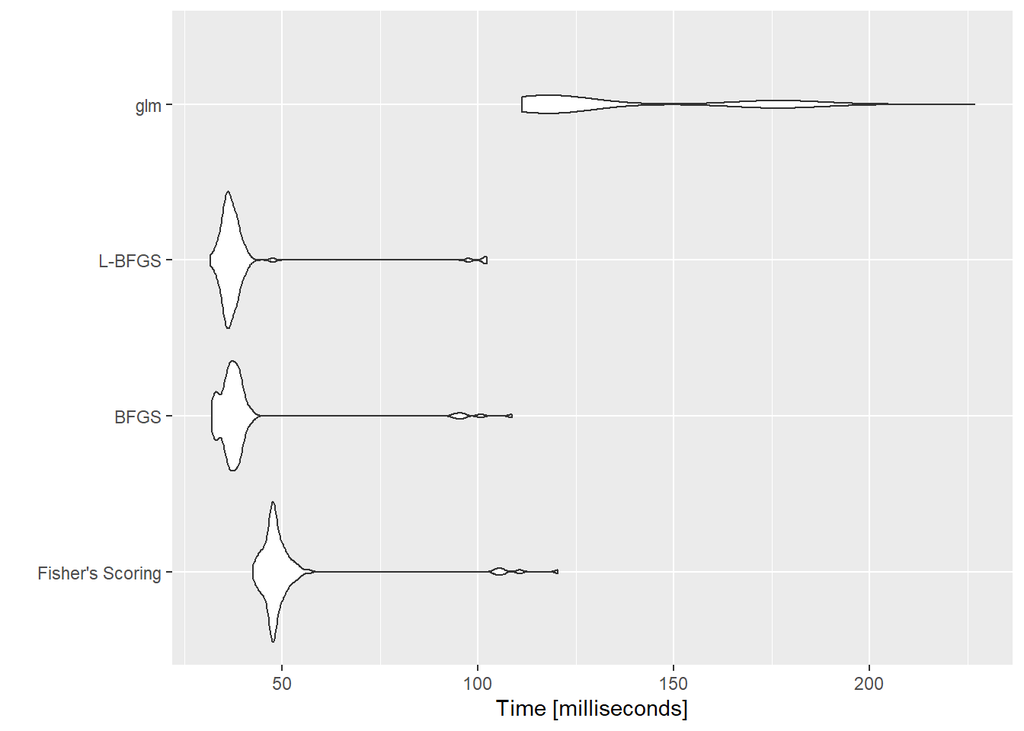

```r
set.seed(8018)

LogisticData <- LogisticSimul(10000, 30)

Times <- microbenchmark("Fisher's Scoring" = BranchGLM(y ~ ., data = LogisticData,
                                              family = "binomial", link = "logit",
                                              method = "Fisher"),
               "BFGS" = BranchGLM(y ~ ., data = LogisticData,
                                              family = "binomial", link = "logit",
                                              method = "BFGS"),
               "L-BFGS" = BranchGLM(y ~ ., data = LogisticData,
                                              family = "binomial", link = "logit",
                                              method = "LBFGS") ,
               "glm" = glm(y ~ ., data = LogisticData, family = binomial))

autoplot(Times, log = FALSE)
```

BFGS and L-BFGS are the fastest with Fisher’s scoring being slightly slower. This shows how BFGS and L-BFGS start to get faster than Fisher’s scoring as the number of covariates increases, although for this number of covariates they are very similar. Again we see that all the methods available from the `BranchGLM` function are faster than the built-in glm function for this simulation.

## Large number of predictors

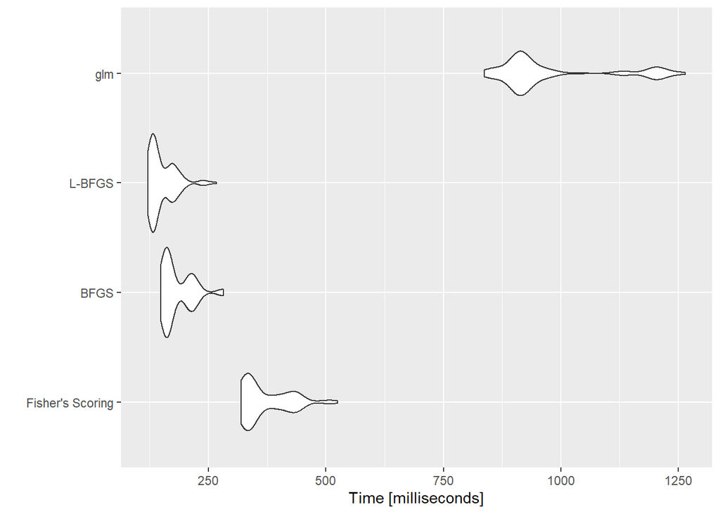

```r
set.seed(60991)

LogisticData <- LogisticSimul(10000, 100)

Times <- microbenchmark("Fisher's Scoring" = BranchGLM(y ~ ., data = LogisticData,
                                              family = "binomial", link = "logit",
                                              method = "Fisher"),
               "BFGS" = BranchGLM(y ~ ., data = LogisticData,
                                              family = "binomial", link = "logit",
                                              method = "BFGS"),
               "L-BFGS" = BranchGLM(y ~ ., data = LogisticData,
                                              family = "binomial", link = "logit",
                                              method = "LBFGS") ,
               "glm" = glm(y ~ ., data = LogisticData, family = binomial))

autoplot(Times, log = FALSE)
```

BFGS and L-BFGS are the fastest methods with Fisher’s scoring taking quite a bit longer, just as expected. This time the difference between the methods from the `BranchGLM` function and the glm is much wider and the methods from `BranchGLM` are much faster.

# Parallel computation

## Small number of covariates and observations

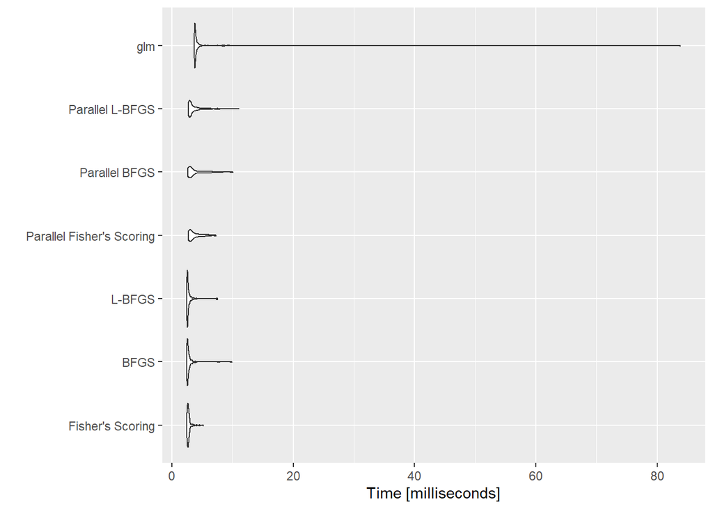

```r
set.seed(18076)

LogisticData <- LogisticSimul(1000, 5)

Times <- microbenchmark("Fisher's Scoring" = BranchGLM(y ~ ., data = LogisticData,
                                              family = "binomial", link = "logit",
                                              method = "Fisher"),
               "BFGS" = BranchGLM(y ~ ., data = LogisticData,
                                              family = "binomial", link = "logit",
                                              method = "BFGS"),
               "L-BFGS" = BranchGLM(y ~ ., data = LogisticData,
                                              family = "binomial", link = "logit",
                                              method = "LBFGS"),
               "Parallel Fisher's Scoring" = BranchGLM(y ~ ., data = LogisticData,
                                              family = "binomial", link = "logit",
                                              method = "Fisher", parallel = TRUE,
                                              nthreads = 5),
               "Parallel BFGS" = BranchGLM(y ~ ., data = LogisticData,
                                              family = "binomial", link = "logit",
                                              method = "BFGS", parallel = TRUE,
                                              nthreads = 5),
               "Parallel L-BFGS" = BranchGLM(y ~ ., data = LogisticData,
                                              family = "binomial", link = "logit",
                                              method = "LBFGS", parallel = TRUE,
                                              nthreads = 5) ,
               "glm" = glm(y ~ ., data = LogisticData, family = binomial))

autoplot(Times, log = FALSE)
```

This shows how the parallel computation employed by `BranchGLM` is not very useful when the number of covariates is small and the number of observations is small and may even slow down the fitting process. Also note that nthreads should be less than or equal to the number of covariates or the overhead of the additional threads will likely slow down the fitting process.

## Large number of covariates and observations

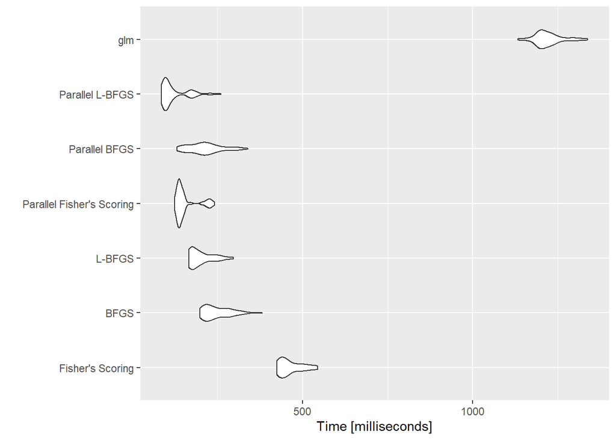

```r
set.seed(60991)

LogisticData <- LogisticSimul(10000, 100)

Times <- microbenchmark("Fisher's Scoring" = BranchGLM(y ~ ., data = LogisticData,
                                              family = "binomial", link = "logit",
                                              method = "Fisher"),
               "BFGS" = BranchGLM(y ~ ., data = LogisticData,
                                              family = "binomial", link = "logit",
                                              method = "BFGS"),
               "L-BFGS" = BranchGLM(y ~ ., data = LogisticData,
                                              family = "binomial", link = "logit",
                                              method = "LBFGS"),
               "Parallel Fisher's Scoring" = BranchGLM(y ~ ., data = LogisticData,
                                              family = "binomial", link = "logit",
                                              method = "Fisher", parallel = TRUE),
               "Parallel BFGS" = BranchGLM(y ~ ., data = LogisticData,
                                              family = "binomial", link = "logit",
                                              method = "BFGS", parallel = TRUE),
               "Parallel L-BFGS" = BranchGLM(y ~ ., data = LogisticData,
                                              family = "binomial", link = "logit",
                                              method = "LBFGS", parallel = TRUE) ,
               "glm" = glm(y ~ ., data = LogisticData, family = binomial))


autoplot(Times, log = FALSE)
```

When there are a lot of covariates and observations, parallel computation can greatly speed up the fitting process when using Fisher’s scoring and can moderately speed up the fitting process when using BFGS or L-BFGS.